# Statistical Consultancy: Getting Started

Dr Christopher McNally

04/08/2021

## Background

Hello, my name is Chris and I am a bioinformatician. I have always had a passion for statistics however, during my PhD I quickly discovered a love for data analysis and programming using the statistical programming language, R. My research revolved around investigating various markers a patient presented with, either from an analysis performed on a biofluid, or a piece of information supplied from a questionnaire. It was my role to determine which of these markers could inform us of a patient’s risk of prostate cancer. And so there is where I began, I taught myself R and took out a few biostatistics books from the library and the end result was quite a respectable model within an app that clinicians could use to stratify a patient’s risk for cancer. I successfully passed my PhD viva and earned my degree in June of 2021.

So how come you are reading this? Well at the time Dr. Emeir McSorley sent the first email informing us about the programme, I had just finished my final draft of my thesis and was a bit disappointed I couldn’t avail of the service. However, I emailed her back and told her I’d love to try and offer to the programme and actually help out other PhD students, as I had done this loads for my PhD friends throughout my degree. To my surprise, she actually said yes and here we are today. I enjoy helping other people out with statistics, mainly for two reasons: One, because I feel people shy away from it and it can be incredibly powerful and useful when done properly. And two, I am passionate about making people aware of bad statistical practices. I wrote a whole chapter in my thesis on why everyone thinking p<0.05 is the be all and end all of data analysis is a very bad idea so I mean business about this!

I am here to try and make your PhD journey a little bit less stressful by giving you advice on the best statistical practices to take based upon my research and experience.

If you would like to check I am who I say I am, feel free to check [my LinkedIn profile](https://www.linkedin.com/in/christopher-mcnally-43793717a/). My email address is mcnally-c21@ulster.ac.uk.

## Research Output

Like I mentioned, I perform all my analyses in R. Now, you do not need to know how to use R in order for to me to help you, but it may be beneficial if you did. If you are interested in learning the language, there are a plethora of different ways you can learn R that you could avail of. I personally used a website called [Udemy](https://www.udemy.com/) and purchased a course for around £10. Another very good choice is [Datacamp](https://www.datacamp.com/), where I believe you get three months of their premium service for free if you sign up with your university email address.

However, if you’re not interested in learning R, that is quite alright as well. My ultimate plan is to provide you with a written report, in the same format as this one, with your research questions answered on it. Supplemented with graphs, statistical tests, code, as well as (and most importantly) my reasoning for each analysis carried out. I will try my utmost best to provide you with this, but we will see how that goes, as everyone’s research is different but I will aim for it to follow that general format.

What I need from you is the following:

- A data frame(s) with all required pieces of information on it
- A well defined data dictionary. A data dictionary can be a list of all the variable names in your data frame and every relevant piece of information surrounding them
- A clear list of research questions for me to work on

And that’s it! This is all new to me as well and I am still finding my feet, so if you have anything you would like to add, discuss or give feedback on, please by all means give me a shout. I like to think I am pretty approachable as just a few months ago I was in your position too. Plus you will be helping me give a better service to other students in the future.

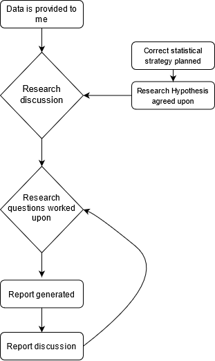

## My Schedule

Currently, I work 9am to 5pm, Monday to Friday as Data Analyst for the Public Health Agency. I plan on working for a few hours on the statistical consultancy work in the evenings on Mondays, Tuesdays and Wednesdays. This is my plan and I most likely will not stick to it but we will just state this for now. In regards to the allocated time, please do not stress about that. My priority is providing you with a professional and well thought out service, so I am not setting a timer for whatever time you have paid for. Sometimes I come across a process I have not learned before so it takes me some time to research and understand it, that tied in with the continual support I plan to give, it most likely will take us past six hours. It is all just part of the process (within reason) and I am continually learning and adapting as well. As long as I achieve my goals of providing a service you are all happy with, I wouldn’t worry.